```python
import platform
import datetime
import sys
import os


your_name, your_code, work_counter = "杜培博", 200507340136, 7
print(f'我是：{your_name}，学号：{your_code}，这是我的第 {work_counter} 次作业。')
print('现在是', datetime.datetime.now())
print('我的机器信息如下：')
print(platform.uname())

print('\n当前工作目录：')
print(os.getcwd())
print('\n当前目录的文件信息如下：')
print(os.listdir())
print('\n我安装包的情况:')
!pip list
```

```
我是：杜培博，学号：200507340136，这是我的第 7 次作业。
现在是 2022-04-17 13:18:18.459429
我的机器信息如下：
uname_result(system='Windows', node='LAPTOP-5PHEQ8I3', release='10', version='10.0.18363', machine='AMD64', processor='AMD64 Family 23 Model 24 Stepping 1, AuthenticAMD')

当前工作目录：
E:\jupyter\curriculum_code\da_tow_下\week07

当前目录的文件信息如下：
['.ipynb_checkpoints', 'Untitled.ipynb']

我安装包的情况:
Package                       Version
```

[output not shown]

[output not shown]

[output cut: 97 more lines]

[output not shown]

# 作业之一

```python
import torch
import numpy as np
```

```python
X = torch.tensor([[1, 2, 3], [4, 5, 6]])
X = torch.tensor([[[1],[2],[3]],[[4],[5],[6]]])
print(X.sum(dim=0,keepdim=True))
X.size
```

```
tensor([[[5],
         [7],
         [9]]])
```

```
<function Tensor.size>
```

### 1 keep dim的作用

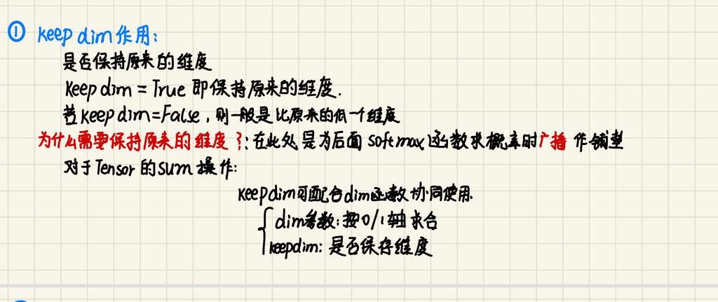

```python
# keep dim
X = torch.tensor([[1, 2, 3], [4, 5, 6]])
print(X.sum(dim=0, keepdim=True))    # 按照0轴，保持原来维度
print(X.sum(dim=1, keepdim=True))    # 按照1轴，保持原来维度
print(X.sum(dim=0, keepdim=False))   # 按照0轴，不保持原来维度
print(X.sum(dim=1, keepdim=False))   # 按照1轴，不保持原来维度
print(X.sum())
```

```
tensor([[5, 7, 9]])
tensor([[ 6],
        [15]])
tensor([5, 7, 9])
tensor([ 6, 15])
tensor(21)
```

### 2 softmax函数

```python
# softmax拆包
X = torch.rand((2, 5))
X_exp = X.exp()
partition = X_exp.sum(dim=1, keepdim=True)       # 保持维度
X_prob = X_exp / partition     # 传播
print(X)
print(X_prob, X_prob.sum(dim=1))
```

```
tensor([[0.1885, 0.1739, 0.8415, 0.2891, 0.7379],
        [0.0167, 0.4740, 0.6636, 0.9255, 0.2218]])
tensor([[0.1483, 0.1461, 0.2849, 0.1640, 0.2568],
        [0.1220, 0.1927, 0.2329, 0.3027, 0.1497]]) tensor([1.0000, 1.0000])
```

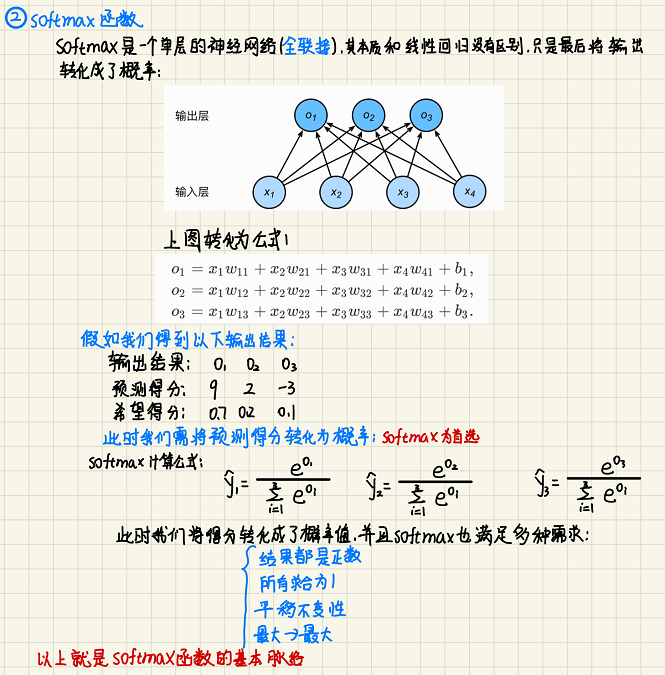

### 3 view序列解包

```python
# view 序列解包
X = torch.range(1, 24 , 2)
# X.view(-1, 4)
X.view(4, -1)
```

```
tensor([[ 1.,  3.,  5.],
        [ 7.,  9., 11.],
        [13., 15., 17.],
        [19., 21., 23.]])
```

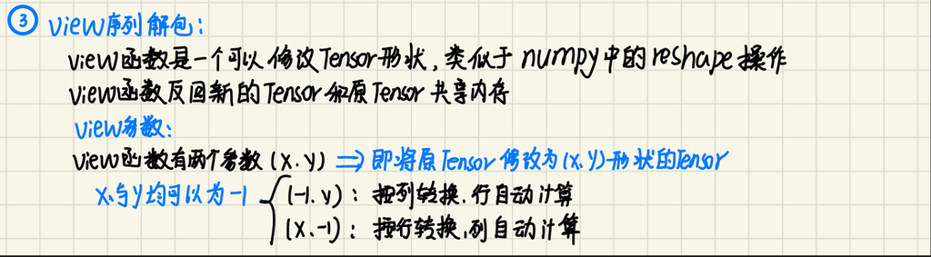

### 4 gather的两种理解（业务理解及索引理解）

```python
# gather
y_hat = torch.tensor([[0.1, 0.3, 0.6], [0.3, 0.2, 0.5]])
y = torch.LongTensor([0, 2])

y_hat.gather(1, y.view(-1, 1))
```

```
tensor([[0.1000],
        [0.5000]])
```

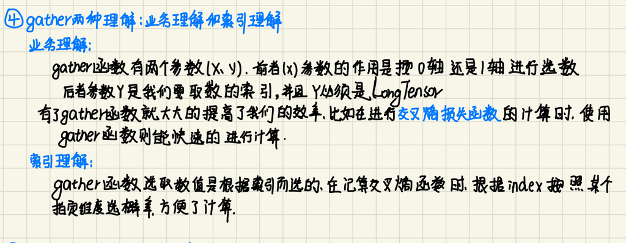

### 5 train_ch3的结构及封装理念

```python
def train_ch3(net, train_iter, test_iter, loss, num_epochs, batch_size, params=None, lr=None, optimizer=None):
    for epoch in range(num_epochs):
        train_l_sum, train_acc_sum, n = 0.0, 0.0, 0
        for X, y in train_iter:
            y_hat = net(X)
            l = loss(y_hat, y).sum()

            # 梯度清零
            if optimizer is not None:
                optimizer.zero_grad()
            elif params is not None and params[0].grad is not None:
                for param in params:
                    param.grad.data.zero_()

            l.backward()
            if optimizer is None:
                d2l.sgd(params, lr, batch_size)
            else:
                optimizer.step()  # “softmax回归的简洁实现”⼀节将⽤到

            train_l_sum += l.item()
            train_acc_sum += (y_hat.argmax(dim=1) == y).sum().item()

            n += y.shape[0]
        test_acc = evaluate_accuracy(test_iter, net)
        print('epoch %d, loss %.4f, train acc %.3f, test acc %.3f' % (epoch + 1, train_l_sum / n, train_acc_sum / n, test_acc))
# 关于 train_ch3
# 这个其实是从零开始和简洁实现的通用函数
# 是工业化封装的“封装”
# 实际的产品都是类似这样的多次封装，请大家体会
```

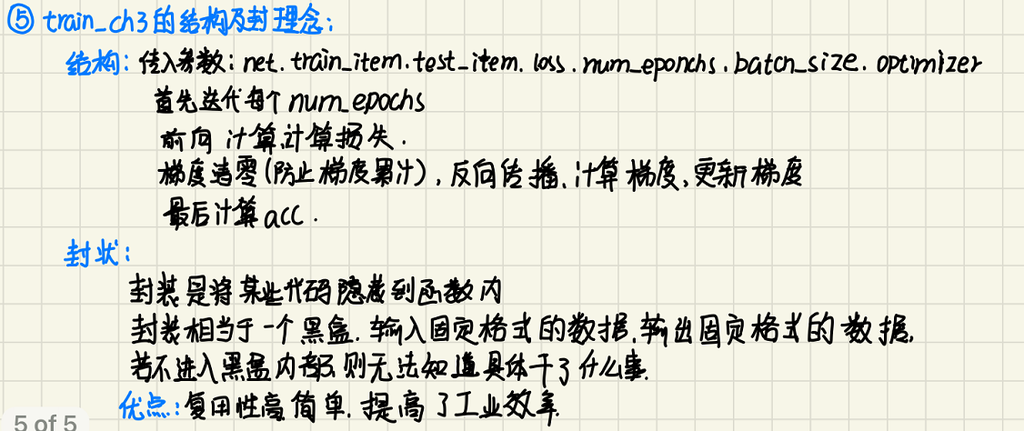

### 6 argmax对softmax结果或one-hot向量的作用过程

```python
y = torch.LongTensor([0, 2])
y_hat = torch.tensor([[0.1, 0.3, 0.6], [0.3, 0.2, 0.5]])
y_hat.gather(1, y.view(-1, 1))
# acc的计算
y_hat.argmax(dim=1) == y
(y_hat.argmax(dim=1) == y).float().mean()
(y_hat.argmax(dim=1) == y).float().mean().item()
```

```
0.5
```

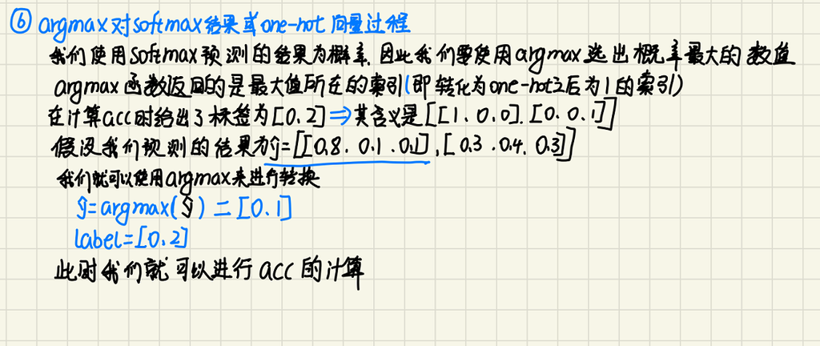

# 作业之二

### 在上面的作业的基础之上，思考一下，面对大量的代码细节，如何尽快开展工作。（可以针对自己的任务进行考虑：学习深度学习、学习Python、学习Pytorch等不同的任务；并思考如果是在实际生产中，涉及项目工期、团队协作、产品质量的情况下，如何保证相关工作可提供有效的产出）

面对大量的代码细节，如果我们看不懂或者不知道如何下手，我们可以进入函数内部，单步执行，了解每一句代码的作用，多思索，总能够看明白代码。

若是在实际生产中，每个人都有自己的工作，在团队协作中，每个人写代码都有自己的风格，但是一个项目往往是由多个人来完成，每个人只负责一小部分，为了保证每个小部分能够完整的结合，我们就要规范的来写代码，比如说某个变量，用相关的单词来表示，让别人见名思意可以有效地提高工作的效率

# 作业之三

### 写简洁实现的softmax回归算法，着重体会框架带来的便利

### 首先导入包

```python
import torch
from torch import nn
from torch.nn import init
import numpy as np
import sys
sys.path.append("..")
import d2lzh_pytorch as d2l
```

### 数据准备

```python
batch_size = 256
train_iter, test_iter = d2l.load_data_fashion_mnist(batch_size)
```

### 用原始的方式定义net

```python
num_inputs = 784
num_outputs = 10

class LinearNet(nn.Module):
    def __init__(self, num_inputs, num_outputs):
        super(LinearNet, self).__init__()
        self.linear = nn.Linear(num_inputs, num_outputs)

    def forward(self, x):  # x shape: (batch, 1, 28, 28)
        y = self.linear(x.view(x.shape[0], -1))
        return y

net = LinearNet(num_inputs, num_outputs)
```

### 初始化模型参数

```python
init.normal_(net.linear.weight, mean=0, std=0.01)
init.constant_(net.linear.bias, val=0)
```

```
Parameter containing:
tensor([0., 0., 0., 0., 0., 0., 0., 0., 0., 0.], requires_grad=True)
```

### 使用的交叉熵损失函数

```python
loss = nn.CrossEntropyLoss()
```

### SGD优化器

```python
optimizer = torch.optim.SGD(net.parameters(), lr=0.1)
```

### 使用train_ch3训练

```python
num_epochs = 5   # 5epochs
d2l.train_ch3(net, train_iter, test_iter, loss, num_epochs,batch_size, None, None, optimizer)
```

```
epoch 1, loss 0.0031, train acc 0.749, test acc 0.792
epoch 2, loss 0.0022, train acc 0.813, test acc 0.807
epoch 3, loss 0.0021, train acc 0.825, test acc 0.815
epoch 4, loss 0.0020, train acc 0.832, test acc 0.814
epoch 5, loss 0.0019, train acc 0.836, test acc 0.826
```

# 作业之四

### 手写MLP算法的原理、说明多层MLP为什么需要使用“激活函数”。

### MLP的算法基本原理

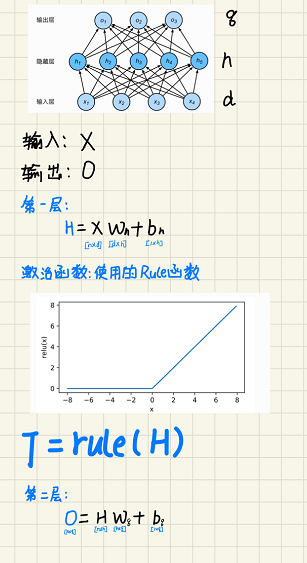

### 为什么要使用激活函数？

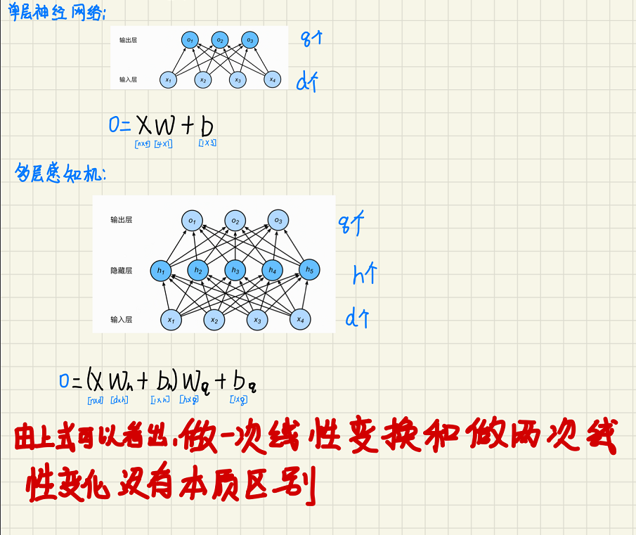

# 在每一层之后加入激活函数，可以大大提升神经网络的复杂性，我们想要的神经网咯希望是能处理复杂的多输入、多输出非线性系统，加入激活函数能够提高神经网络的鲁棒性